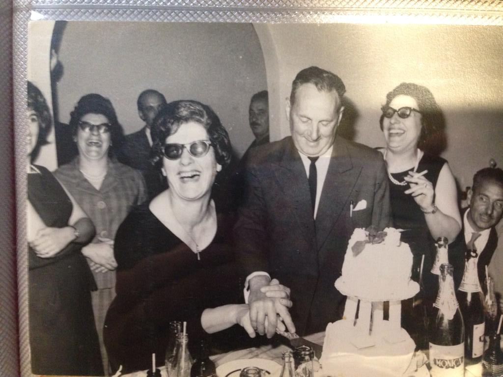

# Historias y recuerdos de la familia Robano en Uruguay

## Historias

Vamos a ir alimentando este sitio con nuestras historias y recuerdos

## Contribuciones

- **Ana Robano**
- **Alberto Robano** (in memoriam)
- **Federico Franco**
  - **Obituario para Alberto**

  En un dia soleado de turismo enterraron a Alberto, el soñado, el Robano más querido. Sin el cambio, moderando en la bajada, sin pedir nada, se fue el casi mi padre. El me subió, parado detras de su codo derecho, al asiento del old mobile del viejo Alberto, el otro extrañado. El me enseñó a manejar a los diez años. El me guardó las milanesas para media tarde. Y la «torta del diablo». El me acompaño a buscar perdices. El me llevó a sacarle entradas para el cine club a la abuela Célica. El me llevó a la playa y al basquet en el Rubino y en el estadio abierto. El me prestó anecdotas de la familia para no ser olvidadas como no quiero a él, olvidarlo ahora. Querido, con su vozarrón ronco que escondia la ternura de sus gestos. Ogro encantador de niños. Soñado como deberían serlo todos los hombres buenos. Murió, tenuemente, desapercibido, dejando tras de si una poderosa corriente de afecto. Envolventes recuerdos de niño del que ahora hombre no sabe como detener la vida. Dejando sin resolución, encuentros y charlas inconclusas se fue Albertito, el mas querido. Un dia de estos lloverá copiosamente, alguien abrirá el portón de su galpón y saldran los gardeles alli latentes. El herrero viejo y rezongón de al lado, su amigo que lo extrañará, mirando los nubarrones grises se secará la cara acusando a la lluvia. Yo, por cierto, no precisare tantas excusas. ¿Como hacer para que esté mas cerca? ff
- **Virginia Robano**

## De Ana (todavía sin editar)

#### Hoy lunes 28 de agosto de 2017 y a pedido de J.F empiezo a escribir historias cortas y sueltas. Dado que las mismas están grabadas en mis retinas no son de fiar (ni las retinas ni las historias).

Lo más antiguo se remonta al año 50, cuando nació Alberto E. Era un domingo de tarde de julio, horrible de gris, lluvioso y yo estaba en la casa de la esquina, de la abuela María Elena con Pochocha, hermana de papa, lo estaban esperando con noticias del hospital que mama estaba internada. Papá movía la cabeza y los tres muy tristes, la cosa no estaba bien.

Pasaron unos días y un día me dejan entrar al cuarto y veo a mama en la cama de bronce con un niño. A veces lo veía al niño metido en una caja semi redonda de madera y con lamparillas, después me entere que era la incubadora que papa le fabrico. Esa incubadora estuvo en el galpón por muchos años.

Según cuentan Alberto no lloro al nacer y le pusieron oxigeno, papa lo fue a ver y como le pareció que el oxigeno no pasaba abrió la válvula un poco mas y así le destapo la nariz y echo la flema, a partir de ese momento reacciono.

Mama dos años antes había tenido otro niño, el 8 de mayo del 47, que se murió al nacer, por eso este bebote era tan preciado, de ahí en adelante fue el consentido.

Dice Chata que se acuerda como lloraba desconsoladamente mama por el niño muerto, según mama me decía que llegaba un hermanito y yo que tenía tres años me sentaba a esperarlo, como no vivió cuando quedo embarazada de nuevo no me dijo nada por las dudas. Papa siempre fue muy especial, difícil de describirlo a pesar de hablar poco tenía un gran sentido de humor, cosa que a mama le faltaba. y mama le decía “Robano tus chistes no me gustan”, siempre se dirigía por el apellido nunca la oí decirle Alberto.

Una vez le hizo el cuento del comunista, “camarada si Ud. tiene 1000 cuadras de campo da la mitad a otro, claro que si, si Ud. tiene 1000 ovejas da la mitad, si y si tiene 2 pantalones da uno, y le contesta NO, entonces le dice cómo es eso daría 500 cuadras y 500 ovejas y no un pantalón. Lo que pasa que no tengo 1000 cuadras ni 1000 ovejas pero si 2 pantalones. Mamá se puso furiosa y le dijo que él era un cavernario que votaba a la 14, papa se reía y nosotros también. Mama hablaba y hablaba papa no contestaba y hacia lo que quería, según mama papa estaba poco en casa, llegaba por el zaguán y salía por el fondo y se iba a ver a la madre que vivía en la esquina, los fondos estaban todos comunicados, menos el de Antonio que se caso y Aleja le hizo hacer un muro.

En esa época los Robano ocupaban media manzana, casas y baldío, campito.

En el año 50 me acuerdo del partido de futbol del 16 de julio, era domingo, escuchaban la radio al mango, puertas y ventanas abiertas, pues mama ventilaba el costurero, yo jugaba en la vereda con un muñeco de plástico blanco y celeste, le puse Julio Pérez porque sentía que lo nombraban en la radio.

Antes de seguir voy a nombrar la familia como estaba integrada: por parte de madre. Mi bisabuela Brígida Demarco vino de Italia a los 16 años, sus hermanos habían venido antes, aquí conoció y se caso con Antonio Scaffo, tuvieron varios hijos Antonio,Enrique,(solterón) Ernesto,Antonita ,Angelica,Maura,Julia y María mi abuela. Mi bisabuela quedo viuda a los 28 años, ella y mi bisabuelo vinieron de aldeas próximas de Salerno.

María se caso con Luis Chassale y tuvieron 10 hijos (Lole, Tito, Manrique, Baby, Chiquito, Alicia, Elsa, Roma, Titina y Célica mi madre. Vivian en una chacra, cerca de donde hoy es La Curva, tenían plantación de duraznos y otros árboles frutales. Como mi abuela era una maquina de parir cuando mi madre tenía 4 años la trajo a vivir con mi bisabuela a la ciudad. A esa edad empezó la escuela, cuando termino sexto con 10 años no le permitieron ingresar al liceo hasta tener 12 años…

Estudio solfeo y piano y francés con Monsieur Coran así que no fue al liceo, a pesar de esto adquirió una cultura envidiable, le encantaba leer, escuchar música, el cine la apasionaba, la literatura, la historia, la política, tenía una visión de todo lo que pasaba, ella se adelantaba a todo, era de vanguardia y muy moderna. Con carácter fuerte e ideas muy claras.

Cuando mi bisabuelo se enfermo del corazón se vinieron todos a la ciudad y mama se fue a vivir con ellos, en la casa de la esquina de Tuboras y Lavalleja y conoció a papa que vivía en Tuboras y Larrañaga. En el año 1934 se fueron todos a vivir a Montevideo, ya eran novios. Mi abuelo se muere y todos los hermanos trabajan en distintas actividades, mamá en una casa de costura Laserre.

Por parte de padre: mi abuelo Antonio Barbato Robano Speranza ( murió antes que papa y mama se casaran)se caso con María Elena Orabe Larrondo y tuvieron 6 hijos : Antonio, Alberto, René(Toto), Oscar (Bebe) ,Julio y María Elena (Pochocha), los Robano venían de la aldea Valle del Angel , los Orabe eran vasco francés.

Ayer fuimos a Sdi del Yi, Chata, yo y Mauricio que atiende los segundos martes de cada mes, y visitamos a Alberto. Mientras Mauricio va al Camedur nosotros divagamos de tiempos viejos, cuando nos veníamos Alberto saca del frezer un block congelado, le saca el nylon y lo quiebra al medio en el respaldo de la silla, me dio la mitad del guiso de lentejas, había que verle la facha, pantalón de piyama a cuadros (de Mercedes), chancletas harapientas y campera similar. Así era papa, nada prolijo, por supuesto que me comí el guiso que estaba riquísimo, además por algo Toto me decía “rastrillo”, siempre me traigo algo, aunque sea un tornillo.

A papa no le gustaba bañarse, decía que se enfermaba, nada que ver con mama que se bañaba dos o tres veces por día. Pero los domingos le tocaba, mama empezaba, e insistía “ Robano anda a bañarte”, entonces se bañaba y volvía a meterse en la cama y le traíamos un mejoral, un vaso con agua y azúcar y otro vaso solo agua. Era todo un rito.

A mama no le gustaba cocinar, pero los sábados de tarde hacia un bizcochuelo para el domingo. Se despertaba temprano y aprontaba el mate dulce y a medida que nos despertábamos íbamos a la cama grande, nos colocábamos a los pies, salvo Alberto que se metía entre mama y papa. Mamá cebaba y cuando le tocaba a papa sacaba el brazo de entre las cobijas, agarraba el mate y tomaba tapado, siempre fue muy friolento. Es decir que acampábamos en la cama, escuchábamos a Gardel en radio Rural y después “La voz de la esperanza”, una audición creo que protestante. Mama se definía como comunista cristiana, combinación que horrorizaba a todos, incluso al cura de la San Pedro.

Cuando se fue mama a Montevideo con toda su flia, todos se hicieron y afiliaron al partido comunista, menos Lole, que se caso con Ester Rossi y se fueron a vivir al Rincón del Bonete trabajaba en Ute, mama nunca se afilio, aunque aportaba y practicaba. Así nosotros también fuimos catalogados de comunistas, hasta Nancy decía que el perro lo era. Lo cual era cierto. Al año de casados, papa que era soldado en la Base Aérea fue dado de baja por indisciplinado, según mama se sentó en el escritorio del Jefe, como era conocido. Papa no lo contestaba, le encantaban los aviones, en esa época eran de tela y madera, supongo que hacía de mecánico y carpintero.

Papa empezó a trabajar en la provisión de Franchi y la regalo a mama una máquina de coser, con la intención de que cosiera (según ella), como había trabajado en un taller de costura.

A partir de ahí papa después entro en la provisión de Sebastián Mondino y mama con su taller.

En el año 50 fue la guerra de Corea y fueron tiempos de bonanza para el país, se vendía mucho corned beef, carne, cueros, chatarra, lo que fuera, papá ahorraba y compro el terreno de calle Varela, donde después construyo estas 2 casas. Las hizo Robles (el Negro ladrillo), bajo la dirección de papa. Papa era mecánico, carpintero, arquitecto, ingeniero, electricista, sanitario, vidriero, podar, inventor etc.

En ese año Perón fue derrocado en la Argentina los aviones revoloteaban todo el día y yo los veía. A Argentina le decían disco 78 por que tenía muchas revoluciones por minuto, nadie duraba, siempre entre militares.

Así que mama armo su taller y no paró hasta su jubilación, ella atendía a las clientes, se elegían telas y modelos, cortaba, probaba , pegaba las mangas y 2 0ficialas cosían , planchaban y una pinche sobrehilaba, sacaba hilos cosía ruedos. Como comunista cristiana que era les pagaba a porcentajes según lo que se cobrara. Todas ganaban bien.

El taller estaba en el primer cuarto, en el segundo dormíamos nosotros, y en tercero era el dormitorio de matrimonio y era donde probaba. En el living atendía las clientas y elegían del muestrario de telas que recibía de Acle, miraban El Officiel revista de modas francesa.

Chata y Cuca se llevaban 18 meses, Chata era la ideóloga y Cuca mas apocada, una vez estando con gente Chata arrastro el toilet al living y se dieron una paliza allí. Mama nunca nos pego delante de la gente pero después que se fue la clienta se la ligaron con la zapatillas Incal (suela de goma) pegaba de la cintura para abajo, nunca en la cabeza y como dolía te quedaba el culo y las piernas ardiendo.

A mama en verano le gustaba andar en casa descalza pero la Incal estaba a mano. Papa siempre calzado, tenía los pies como de bebe, suaves y sin callos ni juanetes. A las 5 de la mañana mama ya iba al costurero, quería estar tranquila para cortar y pensar en el modelo, pero yo en cuanto veía luz por debajo de la puerta me levantaba y ella me decía “ya está colita” me entretenía por un rato en tijeretear retazos. También era de acostarse temprano, aprovechaba a leer, recuerdo verla con un libro en la mano y el otro brazo sosteniendo a Alberto para mamar. Todos nos acostábamos temprano, salvo papa que cenaba con los hermanos Toto y Bebe en el galponcito y venia al rato. Papa era de muy poco comer, mama servía unos platos rebosantes y papa decía “vieja servime como una caja de fósforos”. En la cena siempre se juntaba con los hermanos, hacia asado que comía 2 bocados un pedazo de queso un vaso de vino y según el no precisaba mas. Toto venía con su tota (una damajuana de 5 litros) Bebe un canasto con su botella de vino, queso y salamines. Se reunían pero ninguno hablaba y después cada uno a su casa.

Cristina Olivera es mi amiga de siempre, nos conocimos en el primer año de escuela, las 2 fuimos víctimas de la educación, arrancamos con 5 años en primero, en la escuela del Cañón…

El primer día de escuela papa me llevo de la mano al patio, y me dijo esta va a ser tu maestra y se puso a conversar con ella. Quede impactada, era muy rubia, con el pelo ondulado, hasta las pestañas eran amarillas, tenía una túnica blanquísima, almidonada, zapatos negros con taco y con una gran flor en la solapa. Gran desilusión mi maestra era otra, chiquita, flaca, canosa, medio jorobada y se le asomaba algo negro debajo de la túnica, era la bruja de los cuentos. Papa siempre haciendo chistes que con razón no le gustaban a mama. A partir de ese día tenía que ir sola, no quería ir y me quedaba llorando en el porche de la casa de Julio Robano, entonces avisaban a mama y Carozo me llevaba. Tenía que estar todo el tiempo al lado mío, no lo dejaba ni ir al baño, pues yo me venía para casa. Así llorando siempre hice los 2 primeros años y Carozo también. Cristina también lloraba, creo que de pierna o de verme a mí.

Cuando termino el primer año llamaron a nuestros padres, de Cristina y míos, y les dijeron que convenía que repitiéramos el año, éramos un desastre, la madre de Cristina dijo que bueno y mama dijo “de ninguna manera”, así que me pasaron por no verme llorar.

#### El auto

El primer auto que tuvimos fue hecho por papá, con un rejunte de partes de varios autos, era de darle manija y adelante tenía un escudo Rubgy. Era similar en el tamaño y las líneas de un Tico, todo de madera, con 2 puertas y una chica al medio atrás, vidrios de correr en ventanas laterales, adelante 2 asientos desvencijados apoyados en tablas, atrás tablas de asientos. Esta era La Poderosa.

Papa solía ir a cazar y tenía una escopeta, cuando Federico era chico le pidió a papa que le regalara la escopeta y este le dijo” cuando crepe” pasaron unos días y entonces Fede le dijo “ abuelo cuando vas a crepar? Como se reía papa. Papa adoraba a sus nietos, caminaba con los brazos cruzados atrás y todos los días iba a verlos y Alejandro decía parece que el abuelo trae bizcochos atrás, Ale siempre pensando en comida.

Ítalo trajo un capinchito “Juancito” y cuando creció lo faeno y le pregunte a Ale si no le daba lástima me contesto “papita para papa”, tengo una foto en que esta con Juancito en la falda.

A papa le gustaba cocinar y según mama solo abría latas, bastante sal y picante, para los amigos.

Mama comía sin sal porque tenía presión alta, cuando hacia tuco los domingos, como la cocina Volcán estaba bajo la ventana papá por la ventana le tiraba un puñado de sal a la olla.

A papa una vez se le dio por hacer salsa de tomates y la envaso en botellas de sidra y las dejo en la cocina, una noche empezaron ruidos que sonaban como varios tiros, al otro día se vio que le saltaron los tapones a las botellas y los tomates pegados en el techo. Ni mama ni papa decían malas palabras, como se usa ahora, nunca los oí discutir, a veces mama le hablaba de algo que papa había hecho, cuando todo terminaba papa nos decía “hemos llegado a “un entente cordiale” . A nosotros nos causaba gracia. Cuando no sabíamos el significado de algo nos mandaba a buscar en el diccionario, así que anda y fíjate en internet. Costumbre que mantenemos. Cuando Siomara se ennovio con Augusto y fue a la casa de Carozo y Carmen comento “es una familia rara, si no saben lo que quiere decir algo los mandan al diccionario aunque estén comiendo”. En el gran terreno que había que era de todos los hermanos Robano (menos Antonio) había plantado árboles frutales 3 naranjos amargos, 3 perales enormes, variedad de higueras, parras, ciruelos. El Bebe tenia plantada una quinta, que la cuidaba Toto, Bebe plantaba de todo, compraba las semillas importadas que algunas ya venían en latas de aluminio y después le ponía asa y quedaban de jarro. Toto tenía gallinas y el gallinero estaba cerca de la quinta, tenia pájaros que papa cazaba, cardenales amarillos, rojos y la pajarera cerca de la casa de la abuela. Un día Mauricio y Tono le abrieron las puertas a la pajarera y soltaron los pájaros, algunos se pudieron recuperar.. Toto vivía con la abuela en la casa de la esquina, Bebe cuando joven vivía en una casa donde vive Naya, después Bebe se hizo un dormitorio y un baño arriba de la casa de la abuela, a todos los hermanos les gustaba la construcción. Antonio construyo muchas casas en la manzana de enfrente, que todavía existen, y tenía una carpintería, dicen que Cristina Robano (única hija) heredo 83 casas,2 chacras y un apartamento cerca del estadio Centenario. Fundió todo. En ese terreno es decir el campito Carozo tenia la cancha de futbol, los partidos a 100 o de sol a sol, como se juntaban todos los guises del barrio, los Pimienta, García, Gonzales, Arambillet, Otaño, Torena, Torales , Turban y los que venían de mas lejos. Era una producción más de varones que mujeres, por eso yo me entreveraba al futbol y daba patadas, cosa que Nicolás Pimienta me lo recordó, que le curtía las canillas.

La abuela María Elena aparte de bancar a 6 hijos crio al Chorizo Romero. A papa le encantaba ir a los remates, siempre aparecía con cajas de madera llenas de fierros oxidados, una vez trajo un colchón de lana dividido en tres partes, habían pertenecido a los viejos Florenza, los tiro sobre la mesa del patio y mama se puso furiosa, dijo que esos viejos se meaban y cagaban, por lo tanto nadie los usaría, así que quedaron a la intemperie hasta que papa los saco. Otra vez compro un lote como de 30 macetas, de las cuales solo 5 tenían las tres patas, son las que subsisten en el patio. En una época a papa se le dio por hacer mesas de porland , de distinta forma y tamaño, son las 2 que están en el patio y otra dentro del galpón, hizo una tan grande y pesada, con patas de madera y la puso debajo de los tres perales, patas que no resistieron el peso, se hundió de un lado y quedo en bajada. Le gustaba comer allí con los hermanos en verano, aunque tuviera que sostener las cosas para que no rodaran. También hizo un zarzo para la parra, con vigas de material sin sostén, eran aéreas, por supuesto que con el primer viento se cayó todo.( aprendiz de Dieste). Una vez entro yo al gran galpón que se había hecho al fondo y le estaba cortando la cola a unos cachorritos con el formón y el martillo, salí disparando. En casa siempre hubo perro o venían solos o los traía yo, se llamaban Taco o Igor, hubo un Igor que era un pastor alemán, lo pecho un auto (y eso que la calle era poco transitada), la cuestión que quedo descaderado, y tirado en la calle. Cuando vino papa lo puso sobre una bolsa de arpillera y lo llevo a los escalones del zaguán, le daba todos los días dos mejorales con leche, y allí pasó su convalecencia hasta que pudo caminar. En casa nunca se cerraba el zaguán, solamente en invierno y se hacía mucho frio, en carnaval una vez cuando vino Aurora, que era la empleada de ese momento, encontró a un mascarito durmiendo en el sofá. A las 12 estábamos todos sentados en la mesa y papa llegaba y cuando entraba daba un puntapié seco a la cancel, para que la falleba calzara, es que la empleada cuando lavaba los pisos no la hacía calzar de abajo. Tuvimos una empleada, Juana Barneche, que había sido compañera de escuela de mama, que canelones más ricos que hacía y era muy temerosa y asustadiza, como Chata ya estudiaba medicina tenía un esqueleto humano limpio y barnizado en una valija y yo sacaba el cráneo y en un palo se lo asomaba por la ventana de la cocina. Que susto se daba. Juana los 21 de diciembre no iba a trabajar, se encerraba en su casa (mono ambiente) con todos los hijos porque decía que ese día se terminaba el mundo. Por casa desfilaron muchas empleadas, tenían que limpiar y cocinar, y aparte lavanderas. Fueron pocas las que no robaban y eran faltadoras. Mama luchaba con nosotros 5, mas las empleadas del costurero, mas las sirvientas. Siempre me gustaron los gatos y tenía unos cuantos en el galpón, y una vez me puse 4 o 5 en el pecho, eran chiquitos, y fui al costurero con ellos, Cuca cuando me vio empezó a gritar que era una pesadilla, y mama me hecho. Así que papa un día, a pedido de la barra, los metió a todos en una bolsa y los llevo a la cancha de Nacional a tirarlos. Al otro día cuando me levanto estaban todos en el galpón, resulta que esa cancha es donde ahora es la plaza La Guayreña es decir a las 2 cuadras. Cuca siempre fue debilucha, cuentan que una vez la encontraron llorando detrás de una puerta, que te pasa? Es que el bizcochuelo esta “Nergo”. Mama tenía 2 metas claras con nosotros, una que estudiáramos y otra que nos casáramos. La primera para que tuviéramos una vida mejor que la de ella y la segunda porque abundaban los solterones en la familia y tenia pánico a que quedáramos solteros..Supongo que a esta altura y si nos está viendo puede estar tranquila y considerar, misión cumplida. Mama los lunes iba a Mdeo, en la Onda que la pasaba a buscar por casa muy temprano y de noche la traía, iba al médico López Lomba, elegía las telas, los botones, el Officiel, discos, libros etc. Es decir que ese día yo aprovechaba para hacer otras, travesuras .En el costurero en esa época trabajaban las LLanes, Yola, Brenda y Chocha que era mi madrina de confirmación, era muy asmática. Había descubierto que arriba del ropero papa tenía un revolver niquelado y un lunes ,parándome en el respaldo de la cama llego y lo agarro, entonces llamo a Chocha que venga, cuándo se aparece en la puerta la apunto con el revolver,le dio tal ataque de asma que casi se muere.. Obviamente al otro día me la ligue y papa recibió un rezongo, lo escondió dentro del ropero pero no lo volví a tocar. Una vez que mama no estaba se pelearon Yola y Chocha, esta le tiro con una tijera que quedo clavada en la puerta del patio. Chocha era muy nerviosa, se murió joven en un ataque de asma. Cuando Cristina y yo empezamos la escuela nos compramos chupetes en el almacén del Lolo Barrero (Varela y Tuboras) le sacábamos el aro y lo poníamos entre los dedos para que no se viera, chupeteábamos todo el tiempo. También empecé a mearme en la cama, me despertaba mojada, me envolvía en la cobija y me iba llorando a dormir a los pies de la cama grande. Hasta que un día mama me hablo directamente, sentada ella y yo parada en el baúl, me dijo “si vos te seguís meando en la cama te llevo al Dr. Casas”. A mi mente enseguida vinieron los recuerdos de cuando me atendió, cuando me guarde un botón en la nariz, cuando me corte en el pie y me puso ganchos, es decir que ipso facto deje de mearme. Cuando mama se enojaba con papa, mama le decía “ el lunes me presento en lo del Gallo Pucurull” ( que era abogado) para el divorcio, papa le contestaba “no me vas a dar esa alegría”, siempre con sentido del humor, esta situación se repetía cada tanto. Cuando chicos tuvimos todas las enfermedades propias, yo fui la más resistente, cuando tuve la rubeola no hice fiebre, no deje de ir a la escuela, cuando mama me descubrió las pintitas rojas ya había pasado. Una vez estaban todos enfermos (menos yo) encerrados en el mismo cuarto y yo jugaba en el patio, me llamaban y tenía que pasar corriendo por el cuarto y todos me tiraban con las almohadas, se ve que ya estaban mejor. La Dra.Gracia Scaffo era quien nos atendía y su marido el Dr.Amilcar Casas, que había sido medalla de oro en la facultad, pero en la práctica era mejor ella. Mama le hacia la ropa a Gracia y no le cobraba a cambio de que nos atendía. Todos los días comíamos puntualmente a las 12, porque mama se acostaba 20 minutos para descansar, previo a acostarse dábamos una vuelta, nos subíamos en la Poderosa y papa daba vueltas por las calles peores. Papa manejaba y no usaba los frenos, dejaba que el auto se moviera por inercia, lo apagaba en las bajadas, si aparecía otro auto doblaba en sentido contrario. A la vuelta se tiraban un rato y a las 2 estaban, mama en el costurero y papa en la provisión. A la siesta, cuando no teníamos escuela nos quedábamos adentro, prohido salir, si nos escapábamos hacíamos relajo, como soltar las gallinas del Toto, comer peras o higos verdes, arrancar verduras del Bebe etc. Al final mama nos encerraba en el cuarto de la esquina y ella atravesaba un colchón en la puerta, esos minutos se me hacían eternos, una vez intente pasar por encima de ella y me agarro del tobillo y no pude escaparme. Papa fumaba 2 cigarros al día, uno a la siesta y otro al acostarse de noche, tenía los Camel, o Richmond o Chesterfield en el cajón de la mesa de luz. Carozo se los robaba y fumaba a escondidas, una vez debajo de la cama y yo lo vi, para que no contara me convidaba y me queme la boca, no tenían filtro. Ya adolescente encuentro a Carozo y sus amigos fumando, yo estaba con Sara Ruiz Díaz mi compañera de liceo, y les digo “ le voy a contar a mama” y Carozo nos convida con una pitada y nos dice “ahora anda a contar” y así me jodio.. Carozo era muy ocurrente, resolvía rápidamente los juegos de ingenio, era hábil para arreglar cualquier cosa, sabia de mecánica, de electricidad, resolvía cualquier problema eso si era alérgico a estudiar, era pésimo para los idiomas incluido el español pero rápido en calculo y matemáticas, fue el único que mama no logro que estudiara algo formalmente. A Carozo le encantaba los deportes, futbol y básquetbol, jugaba en Wanderers, cuando chico y a la siesta no podíamos salir jugaba solo en el zaguán al futbol con cuadros de botones, los tenía en una caja e identificados y con otro botón los empujaba.

Cuando jugaba en el campito los partidos eran a cien o hasta que no se veía la pelota, usaba una boina de vasco en la punta de la cabeza.

Papa nos enseño a manejar a todos, Carozo empezó en la Poderosa y el resto en un Ford A rojo, de 2 puertas, después de comer íbamos por las chacras o por Santa Bernardina, los repechos de Pastor o Layera, y nos decía trabalenguas como “Pedro Pérez Pintos pintor profesional pinta paisajes por poca plata” o “por prados perfumados pululan personas pudientes”, siempre me divertía con papa. A veces nos decía “ven que lindo arbolito voy a regarlo” , entonces se bajaba y lo meaba . Un lunes que mama iba a Mdeo nos llevo a Alberto y a mí, recorrimos las tiendas, la botonería Naya , librerías y el Palacio de la Música, siempre volvía con discos y libros, nos cansamos tanto que Alberto ,que era chiquito se sentaba en el cordón de las veredas, por supuesto que nunca más nos llevo. En esa época la Onda salía a las 5 de la mañana y pasaba a buscar a los pasajeros por las casas, a la vuelta los repartía en cada casa, demoraba como 5 horas el viaje, paraba 10 minutos en el bar del Centro en Florida, entraba en todos los pueblos. Si había llovido y el pase Pache estaba crecido se volvía. Era un viaje muy cansador.

Un verano se me ocurrió pasar unos días en Mdeo, con la tía de mama Julia, viuda de Corgatelli y madre de Sergio, vivía en Requena, allí marchamos, yo llevaba cajas con mis muñecas y sus vestidos, el apartamento era chico y oscuro, me entro la depresión y de tarde me llevo al Parque Rodo, cuando llegamos me dijo que se había olvidado del monedero, por lo tanto no subí a ningún juego, por suerte antes de irse mama paso por el apto y me volví con ella. Sergio era militar, hijo único, ya estaba casado pero iba todos los días después de comer a ver a la madre (creía yo) pero era a cagar y prendía fósforos para sacar el olor. Los domingos después de la breve siesta, pasábamos por la panadería de Pablete y comprábamos una gran bolsa de bizcochos y visitábamos a Mama Brígida, nos bajábamos como un malón y atacábamos los bizcochos, Mama nos decía “tú te los traes y tú te los comes”. Tenía un perro galgo de nombre Nerón.  
Cuando alguno de nosotros se enfermaba papa nos traía malta y duraznos en almíbar. En las fiestas traía castañas que las cocinaba en leche y para mama higos secos que venían apilados como monedas y en cajas de madera.

Una vez Cristina me dijo que papa y mama eran como el agua y el aceite y sin embargo se complementaban, a mama no le gustaban los perfumes, el chocolate, el alcohol, las comidas fuertes, si le gustaba leer, la música, el cine, el teatro, filosofar, la historia, la política, el arte en general, le encantaba la timba, la quiniela, la lotería, las cartas, purrete, conga, poker,Gardel, generosa y desprendida con los pesos.

Cuando jugaba a la quiniela, papa le decía, dame esos pesos a mí y yo te aguanto la jugada. Su número preferido era el 7. Papa la plata la invertía en tierra y construcciones y nos aseguro el techo y mama la invertía en nosotros, fuimos a los mejores médicos, especialistas, mejores dentistas, en libros de estudio.

Gracias papa y mama por todo lo que nos dieron y se sacrificaron por nosotros, espero no haberlos defraudado. Cuando termine preparatorios y no sabía qué hacer, tímidamente le dije a mama que quería coser con ella, se le pararon los pelos y me dijo lo siguiente “ queres estar todo el día encerrada, aguantando a las clientas y a las empleadas “ ,con ese panorama dije No, entonces estudia.

#### Veterinaria

Y elegí veterinaria, que es otra historia.

Cuando me recibí y empecé a trabajar y a ganar bien, un día le dije a mama “que suerte que me hiciste estudiar” fue la mayor alegría que le di